# Overall satisfy question 13 analysis

Wanting Tao

June 23, 2017

## for q13s and year

From the overall plot we can see most person responded as Satisfied or Very Satisfied.

Then look at every year’s distribution plot, there is no obvious changes.

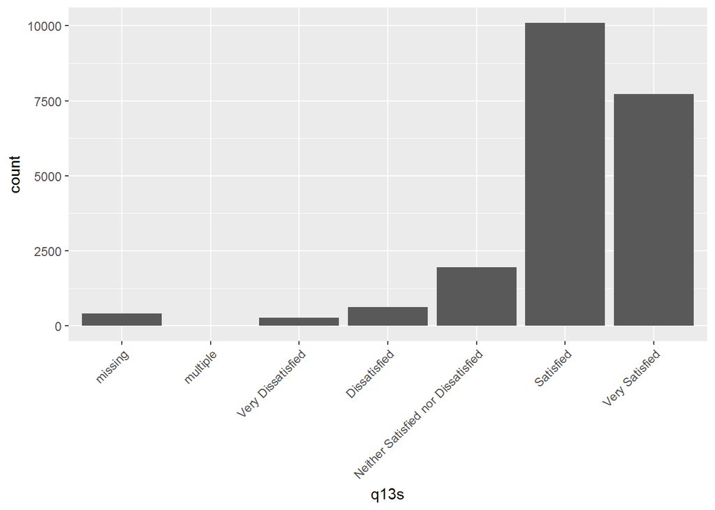

```r
t_q13s <-
  table(dff$q13s, dff$year) %>%
  as.data.frame() %>%
  rename(q13s = Var1, year = Var2, surveys = Freq)

s_q13s <-
  t_q13s %>%
  spread(key = year, value = surveys) %>%
  mutate(total = `13/14` + `14/15` + `15/16`) %>%
  arrange(desc(total))

#table(dff$q13s) # overall distribution for q13s
p0<-ggplot(dff,aes(q13s))+geom_bar()# total distubution for q13s
p0 + theme(axis.text.x=element_text(angle=45,hjust=1))
```

```r
s_q13s%>%datatable()
```

|  | q13s | 13/14 | 14/15 | 15/16 | total |
| --- | --- | --- | --- | --- | --- |
| 1 | Satisfied | 3314 | 3284 | 3503 | 10101 |
| 2 | Very Satisfied | 2704 | 2368 | 2652 | 7724 |
| 3 | Neither Satisfied nor Dissatisfied | 599 | 634 | 723 | 1956 |
| 4 | Dissatisfied | 203 | 189 | 231 | 623 |
| 5 | missing | 144 | 132 | 128 | 404 |
| 6 | Very Dissatisfied | 83 | 95 | 90 | 268 |
| 7 | multiple | 6 | 3 | 1 | 10 |

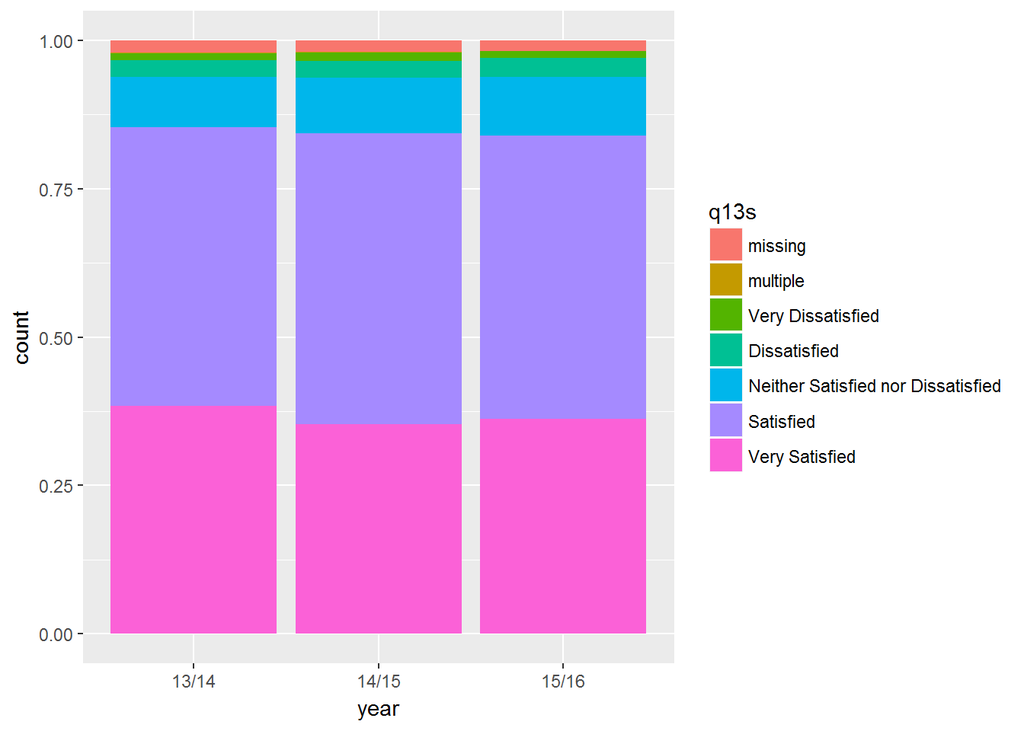

```r
ggplot(dff,aes(year,fill=q13s))+geom_bar(position="fill")# plot for year, parents' education)
```

## college and q13s

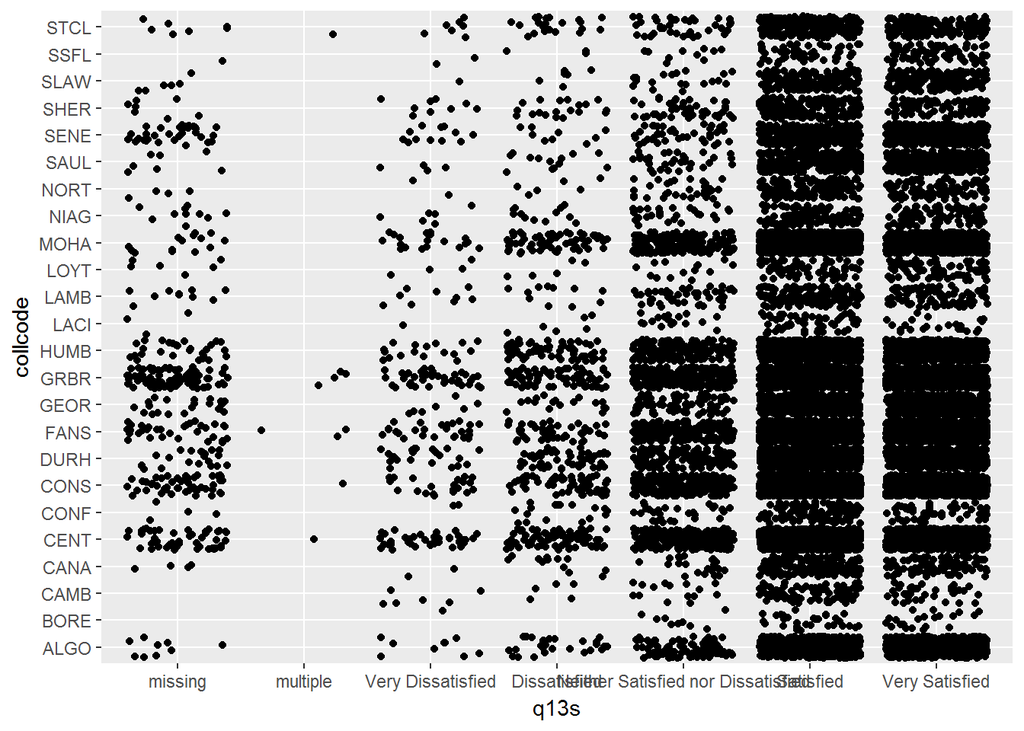

```r
# c_q13s<-table(dff$collcode,dff$q13s) #q13s *college


c_q13s<-
  table(dff$collcode,dff$q13s) %>%
  as.data.frame() %>%
  rename(collcode =Var1, q13s = Var2)

s_q13s<-
  c_q13s %>%
  spread(key=collcode,value=Freq)

ggplot(dff,aes(q13s,collcode))+geom_jitter()# plot for college, parents' education
```

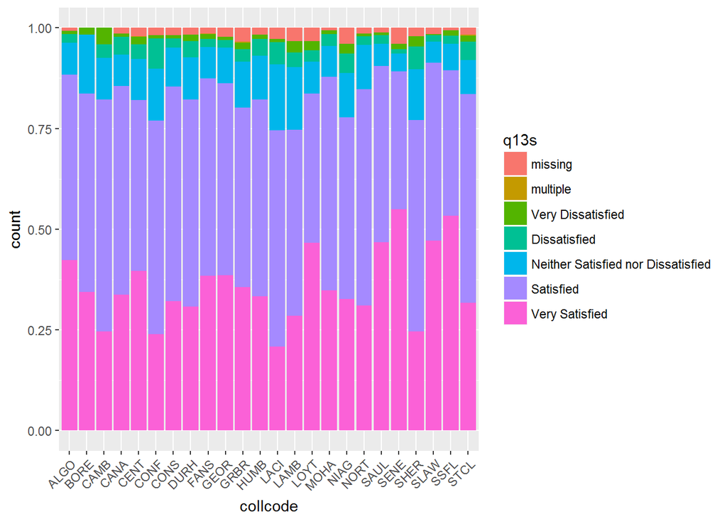

```r
p3<-ggplot(dff,aes(collcode,fill=q13s))+geom_bar(position="fill")# position adjustments plot for q13s in each college
p3 + theme(axis.text.x=element_text(angle=45,hjust=1))
```

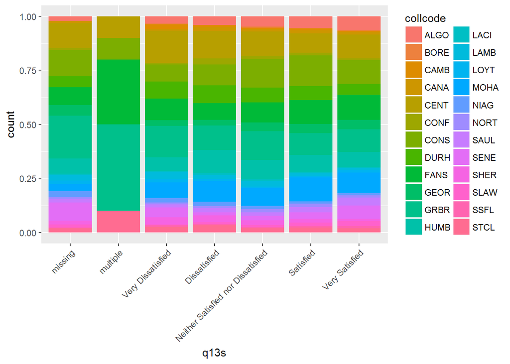

```r
p4<-ggplot(dff,aes(q13s,fill=collcode))+geom_bar(position="fill")# position adjustments plot for each q13s.
p4 + theme(axis.text.x=element_text(angle=45,hjust=1))
```

## gender and q13s

The fist plot shows the response rate of overall question 13 by gender. We can see that Females have an obviously higher proportion of Very Satisfied than males, and fewer proportion chosen Neither Satisfied nor Dissatisfied than males.

```r
g_q13s<-table(dff$gender,dff$q13s) #q72*q13s

g_q13s<-
  table(dff$gender,dff$q13s) %>%
  as.data.frame() %>%
  rename(gender = Var1, q13s= Var2)

sg_q13s<-
  g_q13s %>%
  spread(key=q13s,value=Freq)

sg_q13s%>%datatable() #table for gender and q13s
```

|  | gender | missing | multiple | Very Dissatisfied | Dissatisfied | Neither Satisfied nor Dissatisfied | Satisfied | Very Satisfied |
| --- | --- | --- | --- | --- | --- | --- | --- | --- |
| 1 | missing | 42 | 1 | 12 | 19 | 72 | 326 | 213 |
| 2 | multiple | 2 | 0 | 0 | 0 | 2 | 8 | 2 |
| 3 | female | 49 | 0 | 25 | 40 | 116 | 736 | 964 |
| 4 | male | 298 | 8 | 220 | 554 | 1719 | 8930 | 6477 |
| 5 | uncertain | 13 | 1 | 11 | 10 | 47 | 101 | 68 |

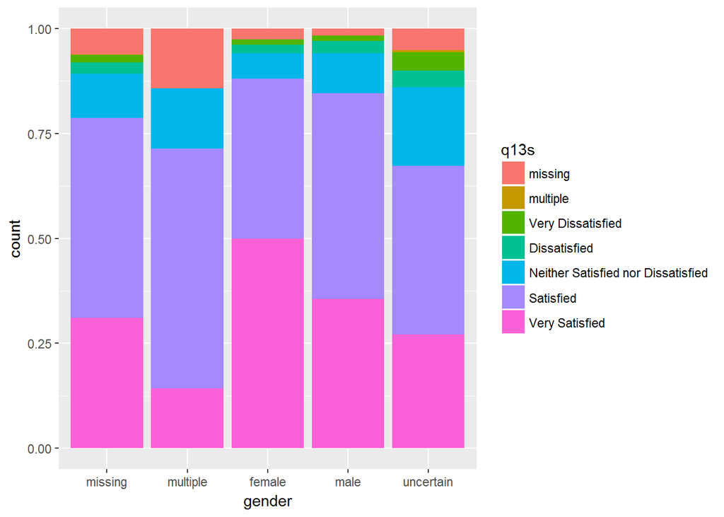

```r
ggplot(dff,aes(gender,fill=q13s))+geom_bar(position="fill")
```

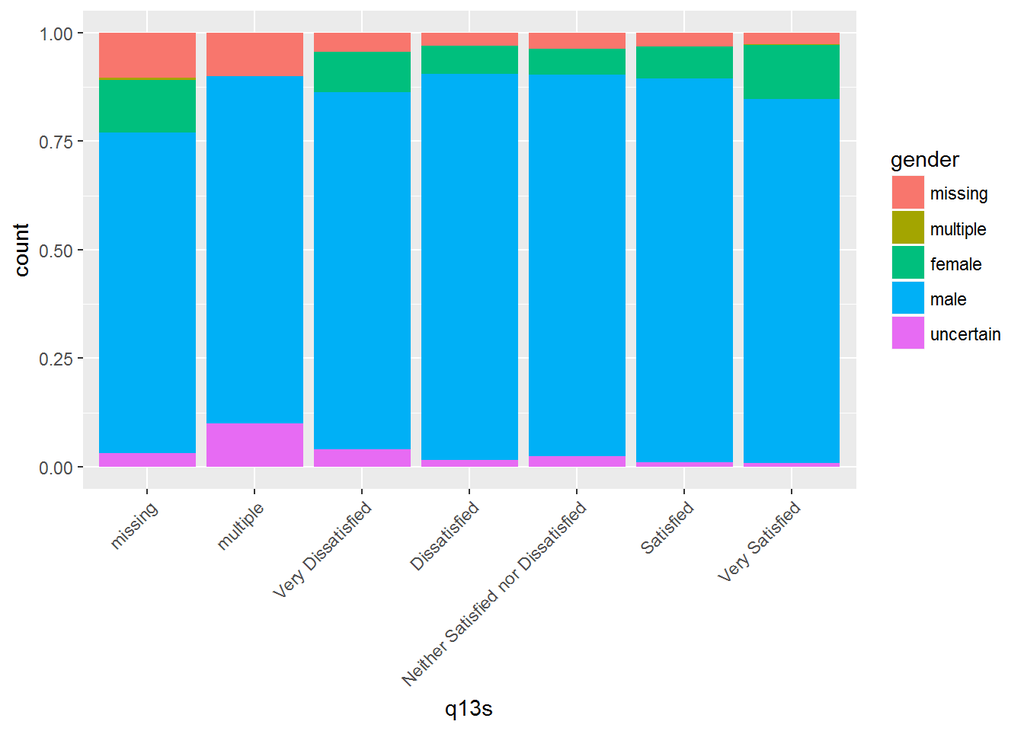

```r
p5<-ggplot(dff,aes(q13s,fill=gender))+geom_bar(position="fill")
p5 + theme(axis.text.x=element_text(angle=45,hjust=1))
```

## top 10 trade in year

Trade 620C has highest Very satisfied rate. Trade 309A has largest proportion among all trades.

```r
t_trade <-
  table(df1$trade, df1$year) %>%
  as.data.frame() %>%
  rename(trade = Var1, year = Var2, surveys = Freq) #dataframe table by trade


s_trade <-
  t_trade %>%
  spread(key = year, value = surveys) %>%
  mutate(total = `13/14` + `14/15` + `15/16`) %>%
  arrange(desc(total))

slice(s_trade,1:10)%>% datatable() #cut the top 10 trades in total
```

|  | trade | 13/14 | 14/15 | 15/16 | total |
| --- | --- | --- | --- | --- | --- |
| 1 | 309A | 1601 | 1478 | 1902 | 4981 |
| 2 | 310S | 831 | 1090 | 1328 | 3249 |
| 3 | 306A | 801 | 752 | 788 | 2341 |
| 4 | 403A | 636 | 587 | 522 | 1745 |
| 5 | 310T | 320 | 394 | 509 | 1223 |
| 6 | 620C | 856 | 0 | 10 | 866 |
| 7 | 433A | 185 | 293 | 270 | 748 |
| 8 | 313A | 180 | 231 | 309 | 720 |
| 9 | 308A | 120 | 193 | 249 | 562 |
| 10 | 415A | 186 | 133 | 123 | 442 |

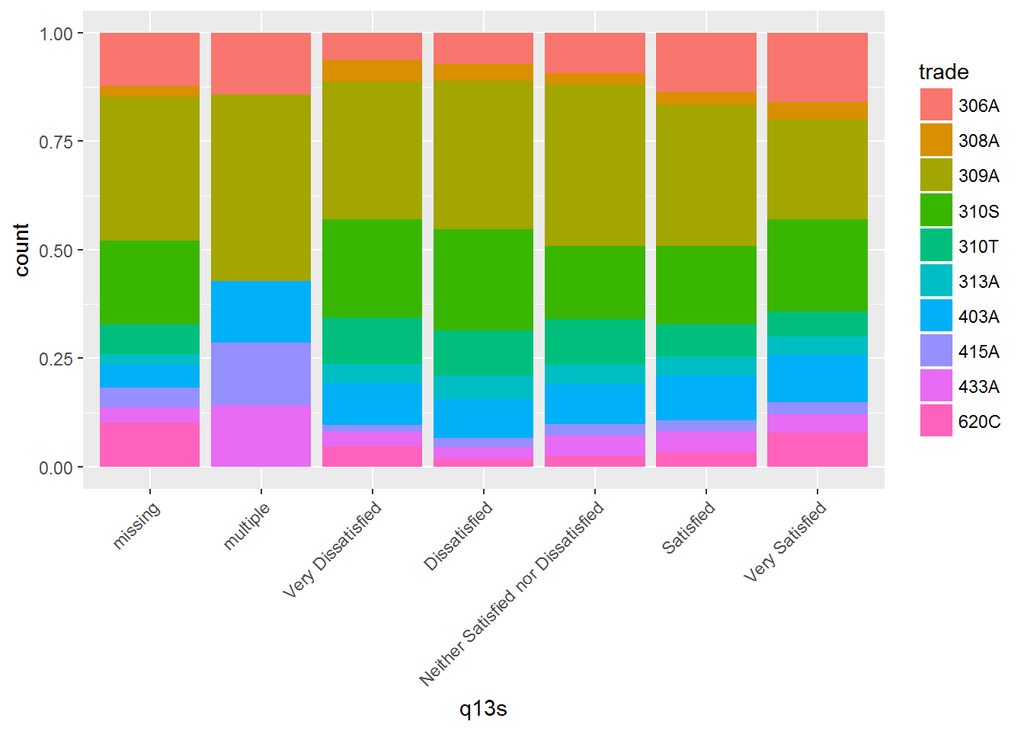

```r
#subset observations
top<-c("309A","310S","306A","403A","310T","620C","433A","313A","308A","415A")
top_data<-filter(dff,trade%in%top)

p1<-ggplot(top_data,aes(q13s,fill=trade))+geom_bar(position="fill") # coop distribution by top trades
p1+theme(axis.text.x=element_text(angle=45,hjust=1))
```

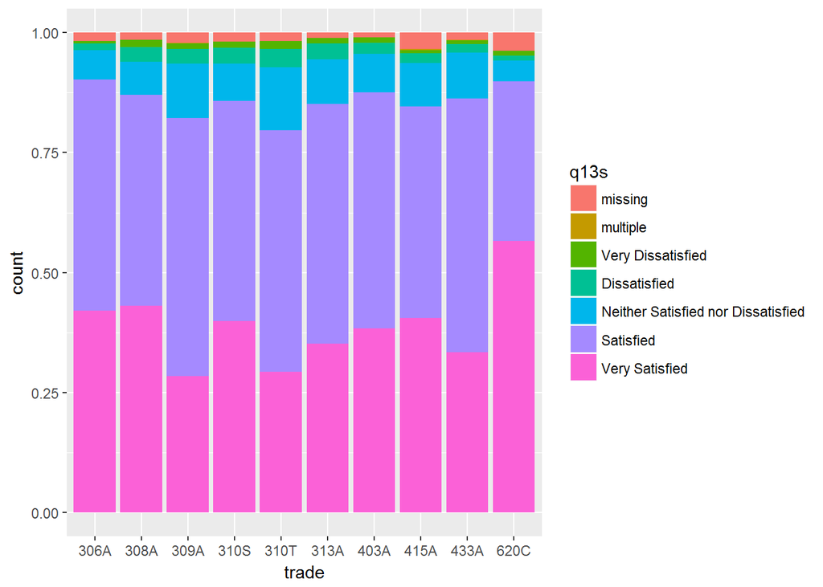

```r
ggplot(top_data,aes(trade,fill=q13s))+geom_bar(position="fill") # coop distribution for top trades
```

## college and year and q13s

SENE has no response after first year(13/14).LACI has only 2 years’responses. The response number of CAMB and SLAW decreasing a lot.

The Very satisifed rate of BORE increase a lot in third year.

```r
cy_q13s<-
  table(dff$collcode_y,dff$q13s)%>%
  as.data.frame()%>%
  rename(collcode_y=Var1,q13s=Var2)

cy_q13s%>%datatable()
```

|  | collcode_y | q13s | Freq |
| --- | --- | --- | --- |
| 1 | ALGO_13/14 | missing | 2 |
| 2 | ALGO_14/15 | missing | 4 |
| 3 | ALGO_15/16 | missing | 3 |
| 4 | BORE_13/14 | missing | 0 |
| 5 | BORE_14/15 | missing | 0 |
| 6 | BORE_15/16 | missing | 0 |
| 7 | CAMB_13/14 | missing | 0 |
| 8 | CAMB_14/15 | missing | 0 |
| 9 | CAMB_15/16 | missing | 0 |
| 10 | CANA_13/14 | missing | 1 |

[output cut: 473 more lines]

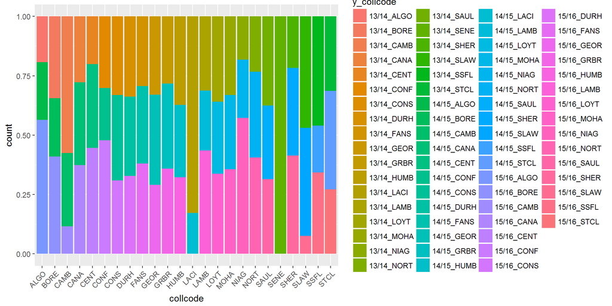

```r
##create new variable combine year and collcode


yc_parents<-
  table(dff$y_collcode,dff$q13s)%>%
  as.data.frame()%>%
  rename(y_collcode=Var1,q13s=Var2)

# college response nubmer change by year
p2<-ggplot(dff,aes(collcode,fill=y_collcode))+geom_bar(position="fill")
p2 + theme(axis.text.x=element_text(angle=45,hjust=1))
```

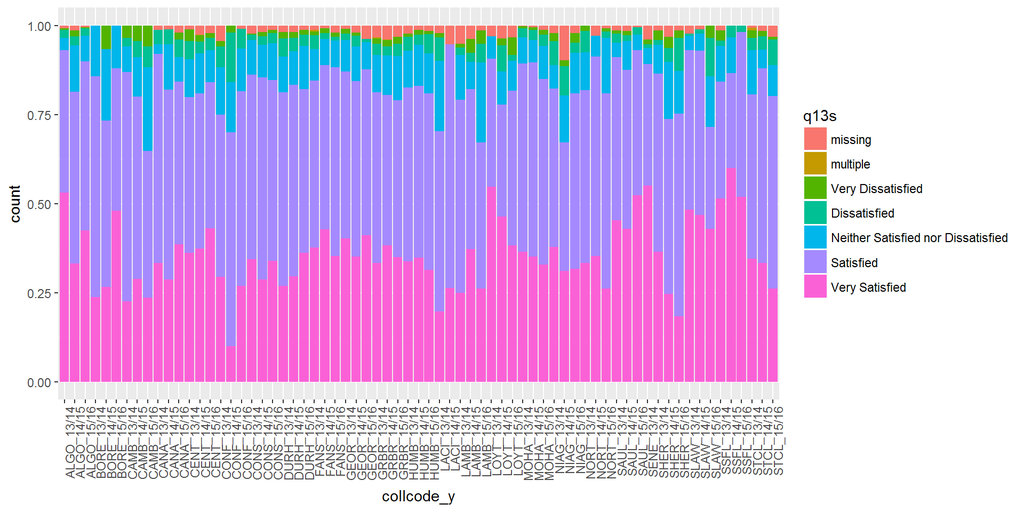

```r
# q13s distribution by college*year and change lable angle
yc_q13<-ggplot(dff,aes(collcode_y,fill=q13s))+geom_bar(position="fill")
yc_q13 + theme(axis.text.x=element_text(angle=90,hjust=1))
```

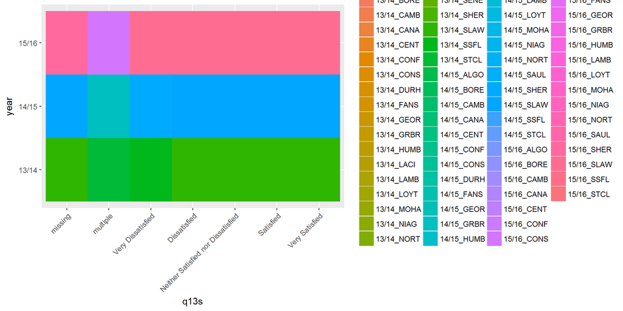

```r
p8<-ggplot(dff,aes(q13s,year))+geom_tile(aes(fill=y_collcode))
p8 + theme(axis.text.x=element_text(angle=45,hjust=1))
```

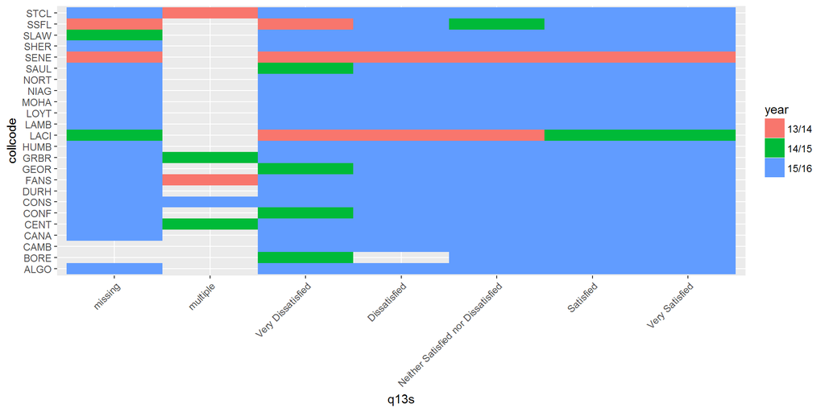

```r
p9<-ggplot(dff,aes(q13s,collcode))+geom_tile(aes(fill=year)) # highest response year of each college for each response rate
p9 + theme(axis.text.x=element_text(angle=45,hjust=1))
```

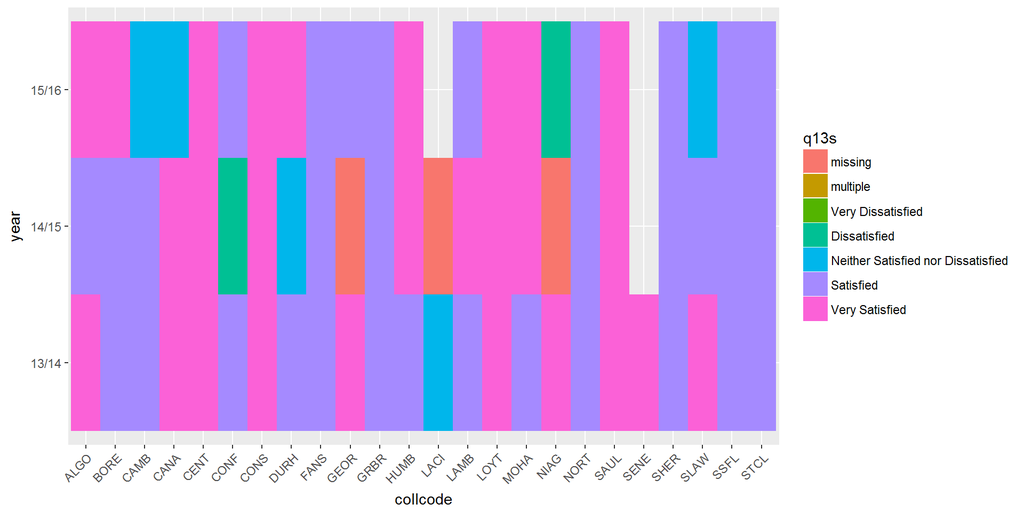

```r
p10<-ggplot(dff,aes(collcode,year))+geom_tile(aes(fill=q13s)) # highest response rate of each college by year
p10 + theme(axis.text.x=element_text(angle=45,hjust=1))
```